# Does the Colour Red Influence Perceived Attractiveness - a Replication Study

*N* removed NAs: 2

*N* removed typo: 1

*N* removed <18: 20

*N* total clean: 127

| Group | *N* | *M*<sub>age</sub> | *M*<sub>rating</sub> |
| --- | --- | --- | --- |
| Control | 63 | 20.7 | 5.62 |
| Experim | 64 | 20.9 | 6.50 |

**Main analysis results**

*t*(125) = -6.47, *p* < .001

[interactive chart not shown]

[figure not shown]

[interactive chart not shown]

# Does the Colour Red Influence Perceived Attractiveness - a Replication Study

Analysing Data, Spring 2020

# Methods

*Participants*: 150 participants initially took part in this replication of Elliot et al’s (2010) original study. All participants in this replication were female. In order to maintain ethical guidelines, participants under the age of 18 were removed from the data (n = 20) and participants who did not provide appropriate, or any, data for their age were also excluded (n = 1, n = 2 respectively). This meant the analysis consisted of data from 127 participants. The mean age of those participants was 20.82 years (sd = 1.87, range = 18-26).

Table 1: *Descriptive Statistics of Age by Condition* (control: white; experimental: red)

| Condition | *M*<sub>age</sub> | *SD*<sub>age</sub> | Min Age | Max Age |
| --- | --- | --- | --- | --- |
| control | 20.7 | 1.91 | 18 | 26 |
| experimental | 20.9 | 1.84 | 18 | 25 |

*Design*: This replication study aims to discover whether colour influences attractiveness of men, for women. As in Experiment 1 of Elliot et al’s study, participants were given a grayscale image of a moderately attractive man for 5 seconds (the exact same image was given to our participants as in the original study – selected from Corneille, Monin & Pleyers’ (2005) photo set). The experimental group received an image with a red background (n = 64) and the control group received an image with a white background (n = 63) bordering the black-and-white image, as colour was the independent variable. The parameters for red were LCh(49.6, 58.8, 30.4) and white was the absence of any colour on the page. The study aimed to measure perceived attractiveness, to see whether viewing a different colour frame around the image of the moderately attractive man would influence the mean ratings of attractiveness. In order to measure our dependent variable of perceived attractiveness, there were three questions presented to the participants, to which they had to respond on a 1-9 rating scale (the higher the rating, the more attractive they found the man). The three items consisted of: “How attractive do you think this person is?”, “How pleasant is this person to look at?” and “If I were to meet the person in this picture face to face, I would think he is attractive.” The scores were averaged into one composite score of each individual’s attractiveness ratings. We hypothesized that participants in the experimental condition - viewing the image with the red background - would rate the target male as more attractive. In order to test whether this prediction was supported by our data, an independent samples t-test was carried out.

# Results

In this close replication, an independent *t*-test was conducted to see whether our findings supported the results of Elliot et al’s (2010) study, where perceived attractiveness ratings were influenced by colour condition. Our results did in fact support the findings of the original study, as participants in the red condition rated the target male more attractive (M = 6.5, SD = 0.79) than those in the white condition (M = 5.62, SD = 0.74) (See Figure 1). This mean difference in ratings (*M*<sub>diff</sub> = -0.88) was significant (95% CI [-1.15, -0.61], *t*(125) = -6.47, *p* < .001) which suggests that the colour red does have a positive effect on perceived attractiveness of men, when viewed by women.

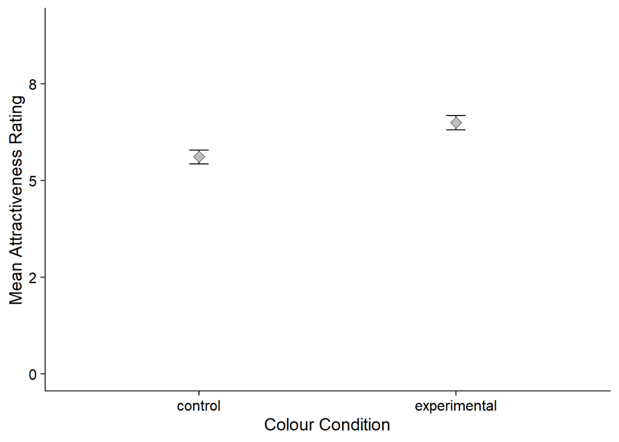

# Discussion

This replication study was conducted in order to understand whether the colour red influenced women’s ratings of male perceived attractiveness. Despite criticism of the original study carried out by Elliot et al (2010), our study’s statistical results supported those findings. Although the difference between the two conditions in our study was slightly smaller than that of the original study (0.88 vs 1.12, respectively), the statistical test we carried out still suggests that the difference was significant. Our study also used a larger sample compared to the original research which may explain the smaller difference in means, however it provides greater support of the power of the effect in larger samples, as well as smaller ones. Thus, our findings provide supporting evidence for the “hypothesised red effect” (Elliot et al, 2010, p.410) on women’s perceived attractiveness of men.

Nevertheless, there have also been numerous replications that have failed to produce the same results, calling into question the credibility of both the red effect and the study originally carried out by Elliot et al. (2010). Hesslinger, Goldbach, & Carbon (2015) attempted to revisit the red effect, carrying out a close replication in a similar fashion to the present research. Their replication did not, however, produce a statistically significant red effect on perceived attractiveness ratings.

Another study carried out by Peperkoorn, Roberts, & Pollet (2016), looked at the red effect on the attractiveness of women instead of men – with a particular focus on the differences in temporal contexts. Although their research wasn’t a replication of the original Elliot et al (2010) study, it is worth highlighting that they also were not able to produce statistically significant differences in ratings of attractiveness between red, white and black conditions. Although, Elliot & Niesta (2008) also explored how the red effect influenced female attractiveness to male participants, yet, contrary to Hesslinger et al. (2015), they were able to find a significant difference between colour conditions. Elliot et al (2010) suggested that until proven otherwise, the red effect should be assumed to be a single mechanism amongst both males and females; therefore, under this consideration, it is important to take note of studies that look at the direction of the effect in both genders.

If the red effect is a single mechanism that operates in the same way in both female and male heterosexual attraction, then Peperkoorn et al’s (2016) and Elliot & Niesta’s (2008) studies provide additional, valuable insight into uncovering the credibility of this effect within its literature, despite looking at opposite genders. Furthermore, the inability to produce consistent evidentiary support for the renowned original studies in the literature has meant the effect of the colour red on perceived attraction should be taken with a pinch of salt.

As mentioned previously, the lack of consistent replication of the original study’s findings is a major issue when considering the reliability and credibility of the red effect. However, it is possible that this is only a symptom of other problems with the research study. Francis (2013) quite extensively describes how the original Elliot et al (2010) paper is tainted with publication bias and therefore does not discuss findings worthy of evidentiary support for the red effect (Francis, 2013). According to his use of the Ioannidis & Trickalinos Test (2007), the probability of rejecting the null hypothesis in the case of every one of the 12 findings is .005 (Francis, 2013), meaning it is nearly impossible for the positive results of every one of those studies to be valid. Although it is not implied this bias was implemented intentionally, there is statistical evidence to suggest either the experiment was run improperly, or some null findings were suppressed from the final report.

In response to this criticism, Elliot & Maier (2013) conducted a replication of their own study with an increased sample size (similar, but slightly greater, than our own replication). Unfortunately, they were unable to provide a statistically significant difference between the conditions. The success amongst the smaller samples sizes of their original study may suggest that the red effect on perceived attractiveness is not as powerful in larger samples, and thus is not generalisable to the whole population. Whilst our study was able to replicate the findings within a larger sample, the inconsistency in the results still leaves room for questioning the validity of the proposed red effect on attraction - perhaps enough to consider whether it ever existed in the first place.

It should also be noted that the sample used by the original study, and thus also used by our close replication, is extremely restricted. With the majority of the participants being Caucasian and of undergraduate student age, the red effect is not given a wide enough platform from which to be examined. Even more so, the small number of target images of men used in the study are also young, Caucasian males. Not only does this inaccurately represent the variation within society (Hesslinger et al., 2015), it also completely disregards individual differences in attraction preferences regarding age, race and other physical characteristics. These individual differences would inevitably act as confounding variables within the study, proving especially problematic within a between-subjects design, where the different conditions could be disproportionately affected.

Perhaps it would be more beneficial to incorporate a within-subject design which allows the researcher to compare directly an individual’s ratings from both conditions, thus removing the interference of individual differences; this would also ensure good methodological practice within the research (Peperkoorn et al., 2016). However, if this is to be carried out in future studies it is important to increase the target stimuli and counterbalance the conditions to prevent the participants from figuring out the purpose of the study.

In terms of future research possibilities, the Hesslinger et al. (2015) study should once again be considered. As well as their replication of Elliot et al’s (2010) experiment, they extended the research onto apparel style as another variable influencing male perceived attractiveness ratings. They found that men wearing formal attire were given higher ratings of attractiveness than men wearing casual attire (sportswear). This effect was even more prominent when measuring perceived status (Hesslinger et al., 2015). This research could be an interesting pathway to pursue within the sexual and romantic behaviour literature, as it explores a more natural and realistic context of establishing first impressions with the opposite sex. This research could also be carried out in terms of male attraction to female targets presented in different apparel styles.

Furthermore, another avenue of this research worth exploring further is the psychological effects on the wearer of red and the influence on their self-perception (Elliot et al., 2010). Elliot et al (2010) used the famous example of Tiger Woods often wearing a red shirt on the final day of golf tournaments to remind others of his respectable position in the golf world, as well as to give himself an ego-boost to improve his performance. Further investigation into the effects of red on onlookers’ and wearers’ perceptions could have great value for the sales and advertising industry (Peperkoorn et al., 2016) in years to come, giving plenty of reason for researchers to continue exploring this domain.

Although our replication provided results to support the original findings produced by Elliot et al (2010), it must be accepted that by replicating the study’s procedures and materials, we may have also replicated the limitations that have come along with it. Ultimately, despite the inconsistency so far, research into the red effect should continue as it has the potential to thrive in various professional areas. Nevertheless, as in all other experimental research, all parties involved with the processes should not ignore critical issues such as publication bias and the file drawer problem.

# References

Corneille, O., Monin, B., & Pleyers, G. (2005). Is positivity a cue or a response option? Warm glow vs. evaluative matching in the familiarity for attractive and not-so-attractive faces. Journal of Experimental Social Psychology, 41, 431–437.

Elliot, A. J., & Maier, M. A. (2013). The red-attractiveness effect, applying the ioannidis and trikalinos(2007b) test, and the broader scientific context: A reply to francis (2013). Journal of Experimental Psychology: General, 142(1), 297–300. https://doi.org/10.1037/a0029592

Elliot, A. J., & Niesta, D. (2008). Romantic Red: Red Enhances Men’s Attraction to Women. Journal of Personality and Social Psychology, 95(5), 1150–1164. https://doi.org/10.1037/0022-3514.95.5.1150

Elliot, A. J., Niesta Kayser, D., Greitemeyer, T., Lichtenfeld, S., Gramzow, R. H., Maier, M. A., & Liu, H. (2010). Red, Rank, and Romance in women viewing men. Journal of Experimental Psychology: General, 139(3), 399–417. https://doi.org/10.1037/a0019689

Francis, G. (2013). Comment publication bias in Red, Rank, and Romance in women viewing men, by Elliot et al. (2010). Journal of Experimental Psychology: General, Vol. 142, pp. 292–296. https://doi.org/10.1037/a0027923

Hesslinger, V. M., Goldbach, L., & Carbon, C. C. (2015). Men in red: A reexamination of the red-attractiveness effect. Psychonomic Bulletin and Review, 22(4), 1142–1148. https://doi.org/10.3758/s13423-015-0866-8

Peperkoorn, L. S., Roberts, S. C., & Pollet, T. V. (2016). Revisiting the red effect on attractiveness and sexual receptivity: No effect of the color red on human mate preferences. Evolutionary Psychology, 14(4), 1–13. https://doi.org/10.1177/1474704916673841